# Bank credit and capital during 1st half of 2020

### Configuration of the query to Bloomberg

All the monetary information throughout the script is downloaded in millions od USD. The best options are either “USD” or “EUR”.

The variables below are the fields to be retrieved from Bloomberg for each bank:

| Bank variables |
| --- |
| IS_PROV_FOR_LOAN_LOSS |
| BS_TOT_LOAN |
| BS_TOT_ASSET |
| BS_LOAN_MTG |
| BS_RSRV_LOAN_LOSS |
| IS_OPER_INC |
| EARN_FOR_COMMON |
| BS_CUSTOMER_DEPOSITS |
| BS_LEV_RATIO_TO_TANG_CAP |
| BS_TIER1_COM_EQUITY_RATIO |
| BS_TIER1_CAP_RATIO |
| BS_TOT_CAP_TO_RISK_BASE_CAP |
| BS_RISK_WEIGHTED_ASSETS |

### Information on sample banks

The sample contains 116 banks, of which 30 are G-SIBs. Below are the list of banks in the sample. In the next section, graphs and tables using data from these banks help understand provisioning behaviour during the pandemic crisis.

| BANK | SHORT_NAME | CNTRY_OF_RISK | ACCOUNTING_STANDARD | GSIB |
| --- | --- | --- | --- | --- |
| WFC US EQUITY | WELLS FARGO &amp; CO | US | US GAAP | True |
| 2016 HK EQUITY | CHINA ZHESHANG-H | CN | IAS/IFRS | False |
| 105560 KS EQUITY | KB FINANCIAL GRO | KR | IAS/IFRS | False |
| CSGN SW EQUITY | CREDIT SUISS-REG | CH | US GAAP | True |
| 7167 JP EQUITY | MEBUKI FINANCIAL | JP | National GAAP | False |
| SHBA SS EQUITY | SVENSKA HAN-A | EU | IAS/IFRS | False |
| STAN LN EQUITY | STANDARD CHARTER | GB | IAS/IFRS | True |
| SAB SM EQUITY | BANCO SABADELL | EU | IAS/IFRS | False |
| BARC LN EQUITY | BARCLAYS PLC | GB | IAS/IFRS | True |
| PNC US EQUITY | PNC FINANCIAL SE | US | US GAAP | False |

[output cut: 106 more lines]

### Time series of provisions

#### By geography

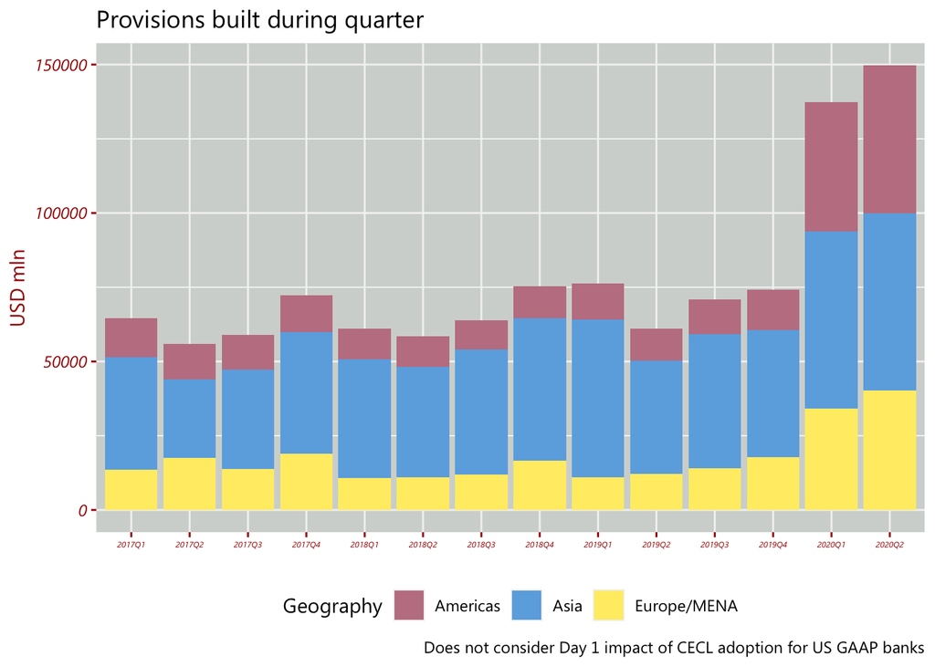

#### By accounting standard

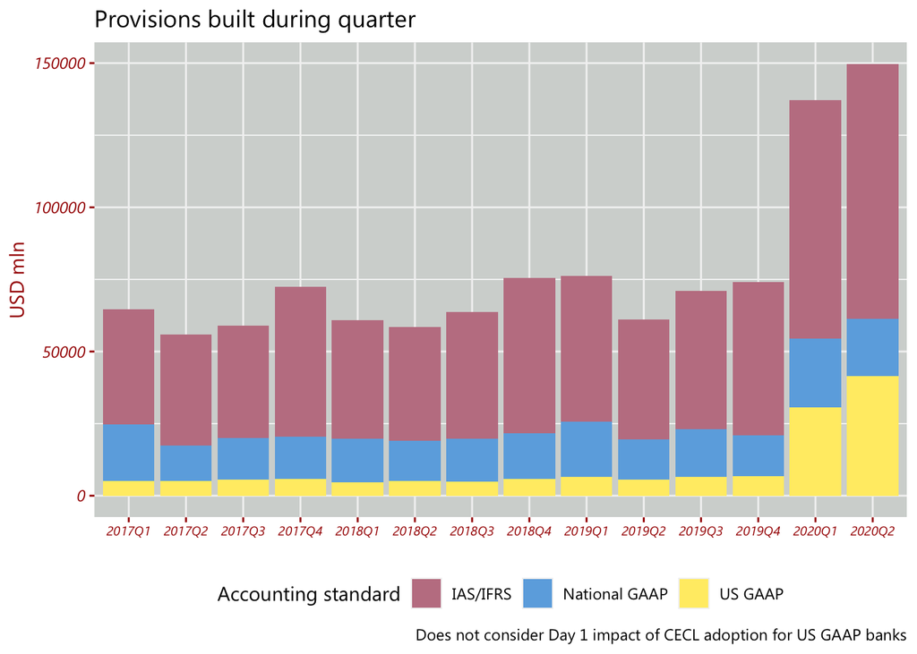

### Loan loss provisions, stock and flow

#### Total stock of loan loss reserves as a percentage of total loans

#### Graph

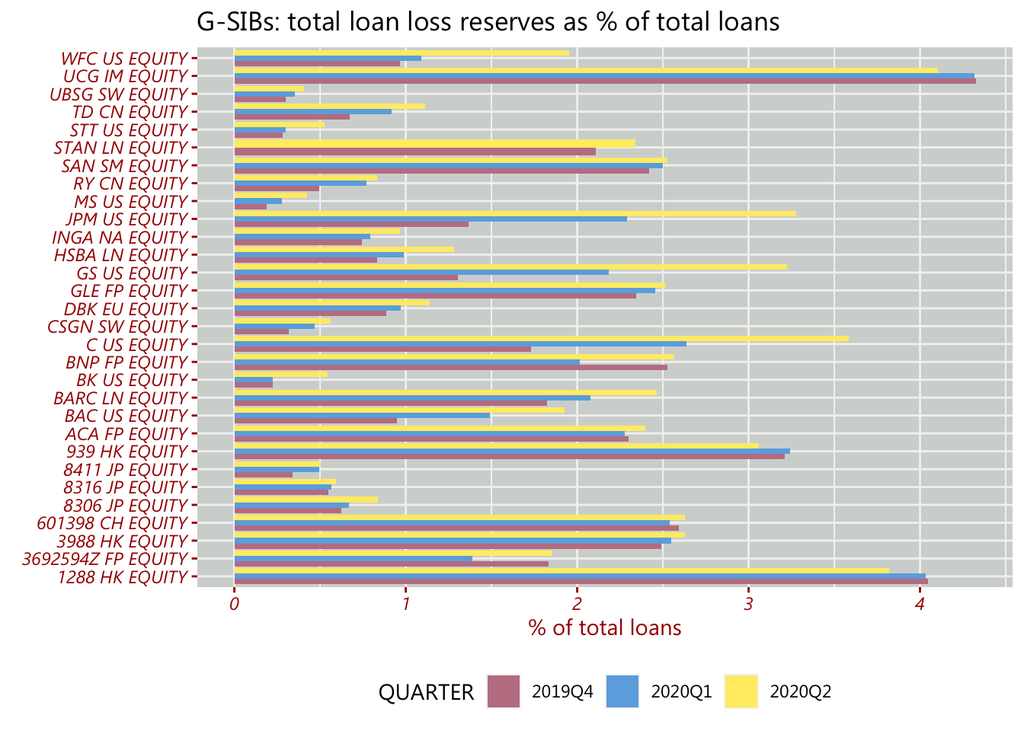

#### Stock of loan loss provisions by bank (G-SIBs only)

The following table contains the data for the graph above. You can download the raw data behind the chart.

| BANK | CNTRY_OF_RISK | SHORT_NAME | QUARTER | LOAN_LOSS_RESERVES_TOT_LOAN_RATIO | QTR_PROVISIONS_TOT_LOAN_RATIO |
| --- | --- | --- | --- | --- | --- |
| RY CN EQUITY | CA | ROYAL BANK OF CA | 2019Q4 | 0.00495830692035663 | 0.000665601556954339 |
| RY CN EQUITY | CA | ROYAL BANK OF CA | 2020Q1 | 0.00770615822221598 | 0.00421898724911923 |
| RY CN EQUITY | CA | ROYAL BANK OF CA | 2020Q2 | 0.00832867187181322 | 0.00100197485795645 |
| TD CN EQUITY | CA | TORONTO-DOM BANK | 2019Q4 | 0.00671062084662803 | 0.00132437892106123 |
| TD CN EQUITY | CA | TORONTO-DOM BANK | 2020Q1 | 0.00918562930251181 | 0.00431877652566795 |
| TD CN EQUITY | CA | TORONTO-DOM BANK | 2020Q2 | 0.0111475095735312 | 0.00294458771927056 |
| CSGN SW EQUITY | CH | CREDIT SUISS-REG | 2019Q4 | 0.00317742874283886 | 0.000478914374262294 |
| CSGN SW EQUITY | CH | CREDIT SUISS-REG | 2020Q1 | 0.00470561146520317 | 0.00186374598360109 |
| CSGN SW EQUITY | CH | CREDIT SUISS-REG | 2020Q2 | 0.00563887541010455 | 0.00098279772255263 |
| UBSG SW EQUITY | CH | UBS GROUP AG | 2019Q4 | 0.00297552780195535 | 2.31333551172427e-05 |

[output cut: 79 more lines]

#### Average quarterly flow of loan loss provisions by jurisdiction

And here you can see the country average for the quarterly build-up of provisions:

| CNTRY_OF_RISK | QUARTER | mean_quarterly_provisions |
| --- | --- | --- |
| CA | 2019Q4 | 0.0994990239007782 |
| CA | 2020Q1 | 0.426888188739359 |
| CA | 2020Q2 | 0.19732812886135 |
| CH | 2019Q4 | 0.0251023864689768 |
| CH | 2020Q1 | 0.130231913059068 |
| CH | 2020Q2 | 0.0861455811952621 |
| CN | 2019Q4 | 0.237430912981027 |
| CN | 2020Q1 | 0.304466551633404 |
| CN | 2020Q2 | 0.271330922842766 |
| EU | 2019Q4 | 0.137634106559123 |

[output cut: 11 more lines]

### Dispersion of provisioning practices

#### Graph with all sample banks

The chart below includes all 116 banks.

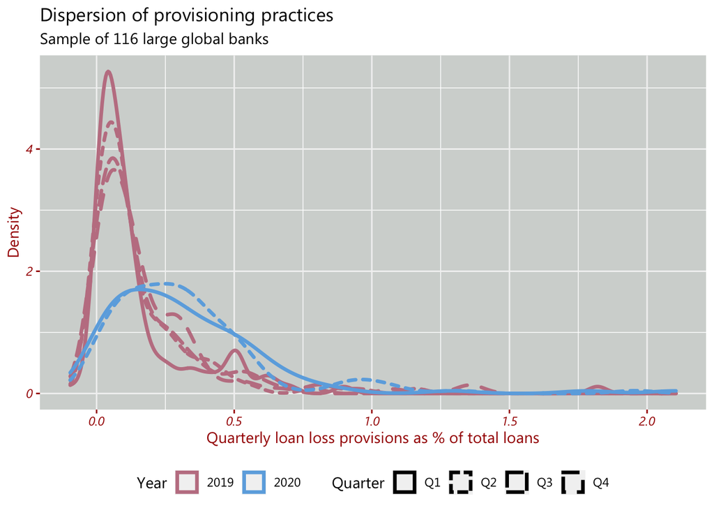

#### By accounting standard

In contrast, the following chart uses the same banks, but they are plotted separately according to their accounting standard.

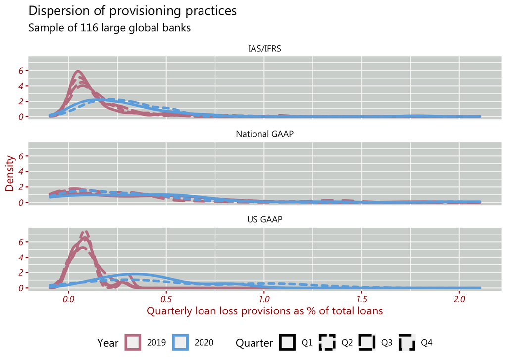

### Provisioning practices and other bank characteristics

This section explores the relationship of provisioning behaviour with bank characteristics such as their profitability, capital level, and RWA density.

#### Provisioning and profitability

Profitability measured by operating income.

[interactive chart not shown]

#### Provisioning and capital

Capital measured by CET1 ratio.

[interactive chart not shown]

#### Provisioning and bank exposure to risk

Exposure to risk measured by RWA density.

[interactive chart not shown]